# Unsupervised Methods

# Clustering

[Back to Homepage](https://alexisidlettewilson.github.io/)

Unsupervised methods typically require more effort to interpret results. No response variable exists in the data nor so we don’t know exactly what the outcome will uncover.

Clustering is a familiar unsupervised method that groups data into clusters based on the analyst’s selected features and the variance of the features. Clustering requires data of different units be normalized and has a few tuning parameters:

- What dissimilarity measure should be used (how do we define “different”)
- What “linkage” should be used (how will we measure the distance between plotted observations)
- What features will be used to generate the clusters

## K-means Clustering

The `k` in K-means clustering represents the number of expected clusters. We define `k` before the analysis.

Create some random data: - Create a matrix with 100 rows and two columns

```r
set.seed(101)
x <- matrix(rnorm(100*2),100,2)
head(x)
```

```
           [,1]       [,2]
[1,] -0.3260365  0.2680658
[2,]  0.5524619 -0.5922083
[3,] -0.6749438  2.1334864
[4,]  0.2143595  1.1727487
[5,]  0.3107692  0.7467610
[6,]  1.1739663 -0.2305087
```

- Create some artificial clustering attribute by creating a table (x_mean) and applying values from that table to the x matrix

```r
x_mean <- matrix(rnorm(8, sd=4), 4, 2)
which <- sample(1:4, 100, replace = TRUE)
x <- x+x_mean[which,]
```

Plot the randomly selected points. They are *col* indicates the points will be colored by the value of `which`. The `which` variable is just the numbers one through four repeated 100 times.

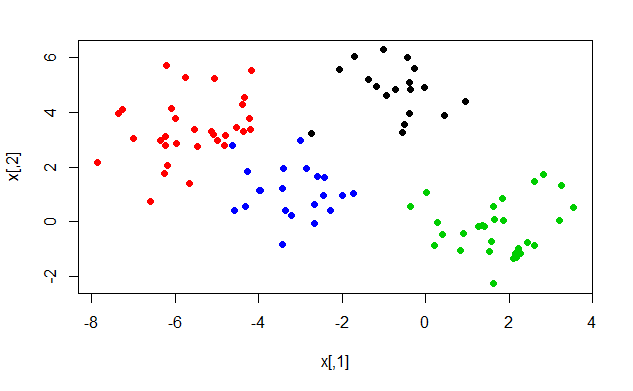

```r
plot(x, col=which, pch=19)
```

Use K-means to find the clusters (we already know the clusters)

```r
km.out <- kmeans(x, 4, nstart=15)
km.out
```

```
K-means clustering with 4 clusters of sizes 21, 30, 32, 17

Cluster means:
        [,1]       [,2]
1 -3.1068542  1.1213302
2  1.7226318 -0.2584919
3 -5.5818142  3.3684991
4 -0.6148368  4.8861032

Clustering vector:
  [1] 2 3 3 4 1 1 4 3 2 3 2 1 1 3 1 1 2 3 3 2 2 3 1 3 1 1 2 2 3 1
 [31] 1 4 3 1 3 3 1 2 2 3 2 2 3 3 1 3 1 3 4 2 1 2 2 4 3 3 2 2 3 2
 [61] 1 2 3 4 2 4 3 4 4 2 2 4 3 2 3 4 4 2 2 1 2 4 4 3 3 2 3 3 1 2
 [91] 3 2 4 4 4 2 3 3 1 1

Within cluster sum of squares by cluster:
[1] 30.82790 54.48008 71.98228 21.04952
 (between_SS / total_SS =  87.6 %)

Available components:

[1] "cluster"      "centers"      "totss"        "withinss"
[5] "tot.withinss" "betweenss"    "size"         "iter"
[9] "ifault"
```

total_SS = the percent of variation explained by the clusters. In this case it is 87.6%.

Create a plot of the results of the *kmeans* function. We overlay the first plot with the *kmeans* plot using a different marker to show a comparison of the two plots.

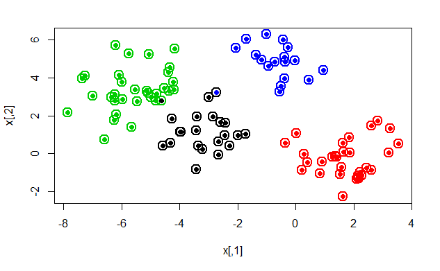

```r
plot(x, col=km.out$cluster, cex=2, pch=1, lwd=2)
points(x, col=c(4,3,2,1)[which],pch=19)
```

We see the *kmeans* function was able to detect our manually created our clusters, mislabeling only two data points.

## Hierarchical Clustering

Use the same data but with the hierarchical clustering method. We do not provide a `k` or number of clusters before hand. This method groups based on a distance parameter, making small groups and then large groups until all the data is in one group. The groupings are plotted in a dendrogram. We then select the number of groupings to be interpreted.

We use the `complete` as he linkage method.

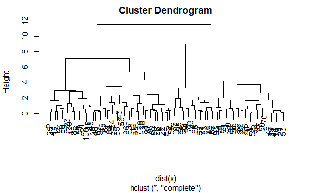

```r
hc.complete <- hclust(dist(x), method="complete")
plot(hc.complete)
```

An analyst would select the cutoff height from which to interpret groupings.

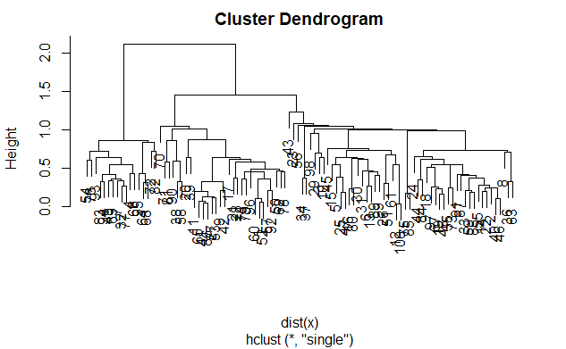

```r
hc.single <- hclust(dist(x), method="single")
plot(hc.single)
```

Compare the results at cutoff point `4` with our manually generated clusters to see if the function found the clusters.

```r
hc.cut <- cutree(hc.complete, 4)
table(hc.cut,which)
```

```
      which
hc.cut  1  2  3  4
     1  0  0 30  0
     2  1 31  0  2
     3 17  0  0  0
     4  0  0  0 19
```

The smaller numbers indicate misclassifications. There are three misclassifications (1+2)

Compare the results at cutoff point `4` with our `kmeans` clusters to see if the function found the clusters.

```r
table(hc.cut, km.out$cluster)
```

```
hc.cut  1  2  3  4
     1  0 30  0  0
     2  2  0 32  0
     3  0  0  0 17
     4 19  0  0  0
```

In this case there were two misclassifications.

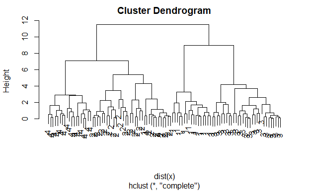

```r
plot(hc.complete, labels=which)
```